# SGG - What explains proteobacterial co-dynamics in the SGG dataset?

André Soares

8 January 2018

## **1 -** High-level taxonomic view of the dataset:

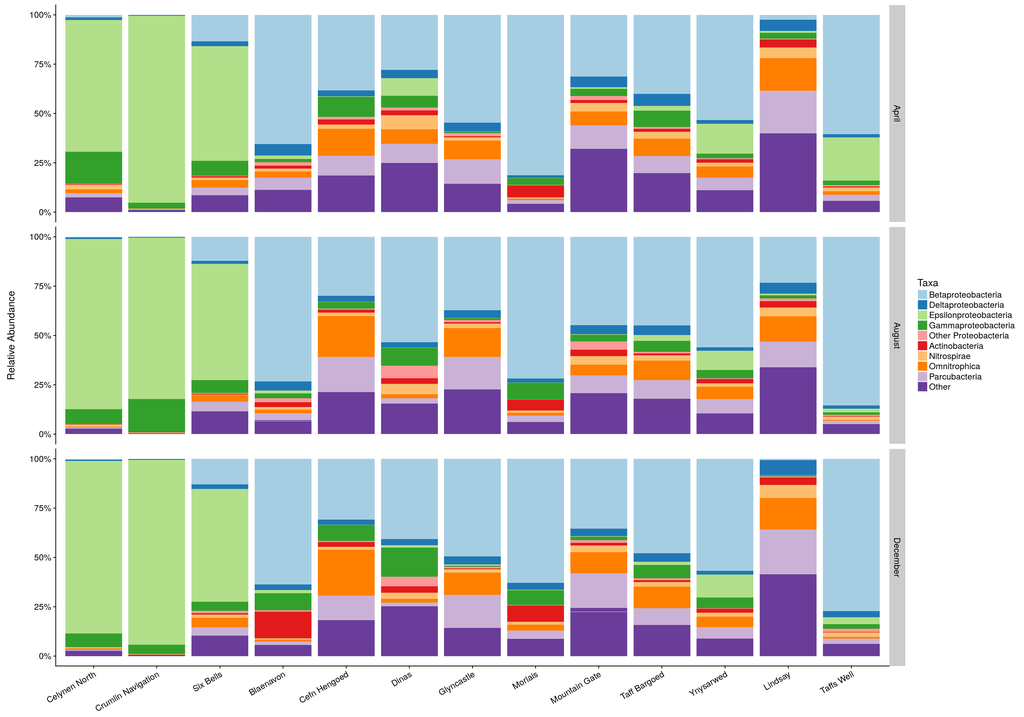

But is this seen at lower taxonomic levels?

## **2 -** Genus-level view of the dataset:

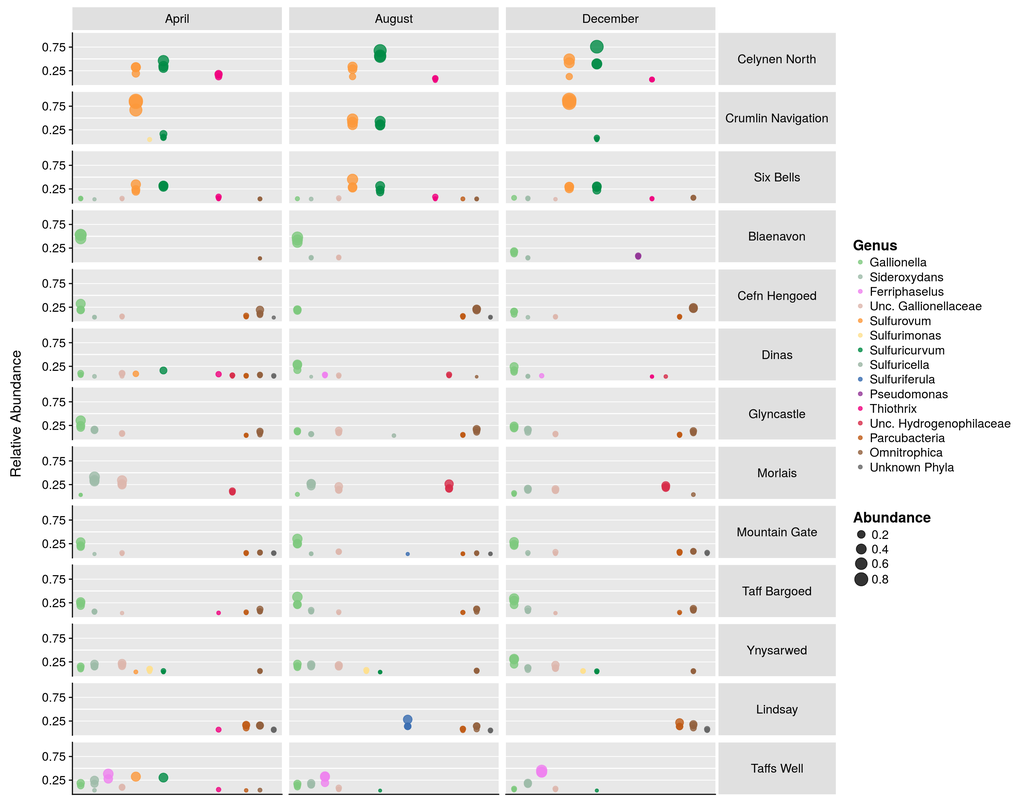

It’s unclear why bacteria with very similar metabolisms (iron- and sulfur-oxidisers) would co-occur and seemingly compete for dominance of the profiles this way. What could drive this? What do available genomes for Sulfuricurvum, Sulfurovum, Gallionella, Sideroxydans and Ferriphaselus say?

## **3 -** Genomic information for the most abundant genera in the dataset:

#### **Gallionella:**

Gallionella is an microaerophilic iron-oxidiser that uses $Fe^{+2}$ solely as electron donor. It’s equipped for aerotaxis and motile. Grows preferrably at lower temperatures (6ºC) and is unable to grow at 30ºC. Carbon metabolism works through the RubisCO pathway.

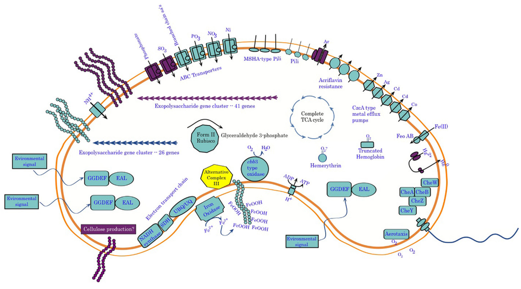

#### **Sideroxydans:**

Sideroxydans is a motile microaerophilic iron-oxidiser that uses $Fe^{+2}$ as electron donor but also has the potential to use thiosulfate. This is due to the presence of a *sox* operon (ABXYZ) in its genome. Grows preferrably at higher temperatures (30ºC) and is unable to grow at 6ºC. Carbon metabolism works through the RubisCO pathway.

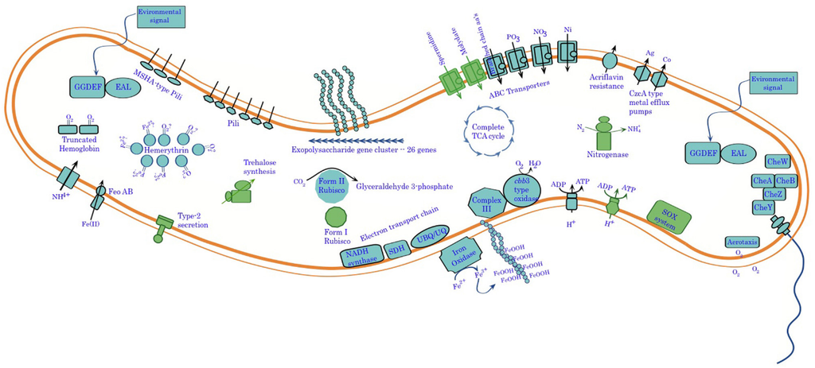

#### **Ferriphaselus:**

Ferriphaselus is a motile microaerophilic iron-oxidiser that uses $Fe^{+2}$ solely as electron donor. However, it lacks the *Mto* gene cluster to oxidise $Fe^{+2}$ and seems to use instead a panoply of alternative FeO metabolisms specially including *act* (AB1B2CDEF). Further studies are needed to prove its capacity to grow on sulfur species, since not only it has a *sox* operon (ABXYZ) in its genome but also *dsr* (ABEFHCMKJOPN), *rdsr* (DAGC), *Sqr* and *soe* (ABC). Grows preferrably at higher temperatures (30ºC) and is unable to grow at 6ºC. Carbon metabolism works through the RubisCO pathway.

#### **Sulfuricurvum:**

Sulfuricurvum is a motile facultative anaerobe that can use sulfide, sulfite and elemental sulfur as electron donors along with oxygen, nitrate and nitric oxide as electron acceptors. To allow that number of electron donors, Sulfuricurvum not only uses the *sox* (ABXYZ) operon, but also *Sqr* (DF), *Sor* (AB) and *Fcc* (AB). 4 plasmids were found in Handley *et al.* (2014) with one associated to nitrogen metabolism. Carbon metabolism works through the rTCA cycle.

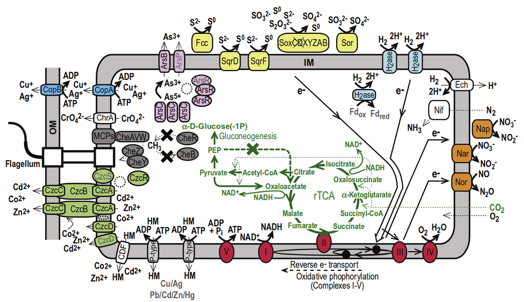

#### **Sulfurovum:**

Sulfurovum is a non-motile facultative anaerobe that can use thiosulfate and elemental sulfur as electron donors along with oxygen and nitrate as electron acceptors. Sulfurovum only uses the *sox* (ABXYZ) operon, as opposed to Sulfuricurvum. Carbon metabolism works through the rTCA cycle.

### Genomic hits for FeOB metal resistance potential:

**Genome Accessions:** NC_014394.1, NC_013959.1, BBTH01000001:BBTH01000023, NZ_CP011308.1, CP003920.1.

Genome annotation done with `PROKKA v1.12` (https://github.com/tseemann/prokka), functional annotation with `EggNOG-mapper` (http://eggnogdb.embl.de/app/emapper#/app/emapper).

| Metals | Gallionella | Sideroxydans | Ferriphaselus | Sulfuricurvum | Sulfurovum |
| --- | --- | --- | --- | --- | --- |
| Mercury | 3 | 0 | 0 | 0 | 0 |
| Arsenic | 3 | 2 | 4 | 3 | 3 |
| Cobalt | 14 | 4 | 6 | 4 | 5 |
| Zinc | 3 | 2 | 2 | 2 | 4 |
| Copper | 1 | 5 | 2 | 3 | 6 |
| Manganese | 1 | 1 | 0 | 1 | 1 |
| Selenium | 1 | 1 | 2 | 0 | 2 |
| Magnesium | 0 | 1 | 2 | 0 | 1 |
| Heavy metal efflux pump/-related | 15 | 5 | 7 | 2 | 3 |
| Mg/Co Transport | 3 | 2 | 2 | 2 | 3 |
| Sodium exchange-related | 6 | 6 | 4 | 1 | 6 |

As advertised, *Gallionella* seems to be a lot more prepared to thrive in heavy-metal-rich environments. Maybe that gives this genus an advantage in colonizing most of the iron-rich sites in South Wales. Not a lot can be taken from this since these genomes were generated from far away sites across the world. They do, however, reveal the potential in some of these genera for competitive advantages in heavy-metal-rich sites.

Ok then, so do any of the metals we measured have any impact on the relative abundance of any of these genera?

## **4 -** Metals and relative abundance of important genera:

Can we try and get numbers out of these supposed relations?

What follows is a heatmap of *Pearson* correlations. *Pearson* assumes linearity between variables as well as normal distributions of data and is sensible to transformation. Normalization of the metadata variables to a 0-1 scale didn’t change results here.

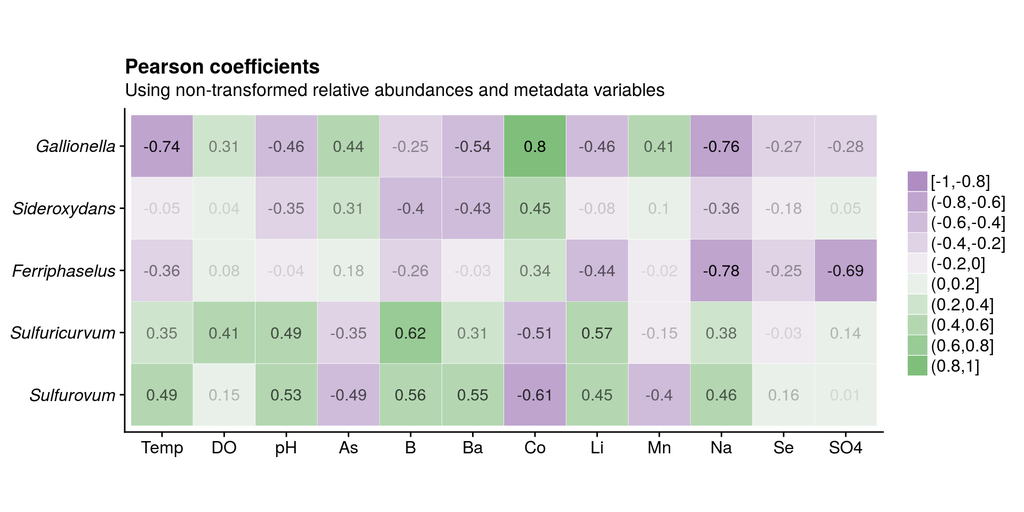

So from *Pearson* correlations it looks like each of the relative abundance of each FeOB is defined by a specific set of metadata variables that probably drives co-occurrence across the dataset. **Gallionella** is very positively correlated to cobalt concentrations, less positively to manganese and arsenic and negatively to barium, temperature and sodium concentrations. The first two make sense since this genus is known to grow better a lower temperatures and has had its potential for manganese, cobalt and arsenic resistance reported [here](https://www.ncbi.nlm.nih.gov/pmc/articles/PMC3770913/).

Regarding **Sideroxydans**, it seems the only meaningful correlations point positively to cobalt and negatively to barium and boron. Again, at least some part of this may have been predicted by [previous work](https://www.ncbi.nlm.nih.gov/pmc/articles/PMC3770913/), but barium and boron aren’t directly mentioned. Unlike **Gallionella**, **Sideroxydans** doesn’t show correlations towards either temperature, dissolved oxygen or pH.

**Ferriphaselus** stands out as being negatively correlated to sulfate and sodium concentrations. Not sure what this means but sulfate isn’t a direct indicator of elemental sulfur, sulfite or sulfide concentrations. Aside from that, weak negative correlations to lithium and temperature and positive correlations seen from cobalt.

A number of correlations arise with **Sulfuricurvum**, where it seems that it’s strongly associated to boron and lithium concentrations, followed albeit in a weaker fashion by dissolved oxygen and pH. It’s also negatively associated to the presence of cobalt.

**Sulfurovum** presence is marked by positive correlations (>0.45) towards temperature, pH, sodium, lithium, barium and boron. It’s also strongly negatively correlated to cobalt presence.

Sodium seems to play a relatively important role across the dataset albeit no direct cause for this effect, from what I know. Sodium is the weakest ion to be adsorbed onto mineral surfaces and that may be the cause of its abundance, but how does it affect microbial communities?